# Three Birthday Problem

R. G. Cronce

10/22/2019

## Overview

This all started with a simple problem: how many people do you need for more than 50% probability that three or more of them share the same birthday.

This is substantially more difficult to answer than the standard two person problem.

We can attempt to solve this with Monte-Carlo as shown below:

```r
birthday <- function(num_people=10, num_trials=100000, num_collisions=3) {
  n=0
  for (i in 1:num_trials) {
    m=tabulate(sample(365,num_people,replace=T))
    n=n+(any(m>=num_collisions))
  }
  return(n/num_trials)
}
```

We can explore the space and get a rough idea of the answer:

```r
n=c()
p=c()
for (num_people in seq(10,200,10)) {
  n=c(n,num_people)
  p=c(p,birthday(num_people,100000,3))
}
```

Examining the results shows the answer is probably between 80 and 90:

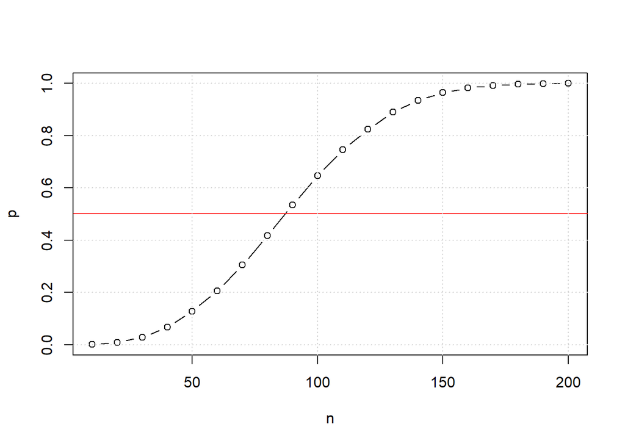

```r
plot(n,p,type='b')
abline(h=0.5,col='red')
grid()
```

Zoom in on the region of interest:

```r
n=c()
p=c()
for (num_people in seq(80,90)) {
  n=c(n,num_people)
  p=c(p,birthday(num_people,100000,3))
}
```

the result shows that the answer is very close to n=87. We will have to work a little to see if the result is above or below this value:

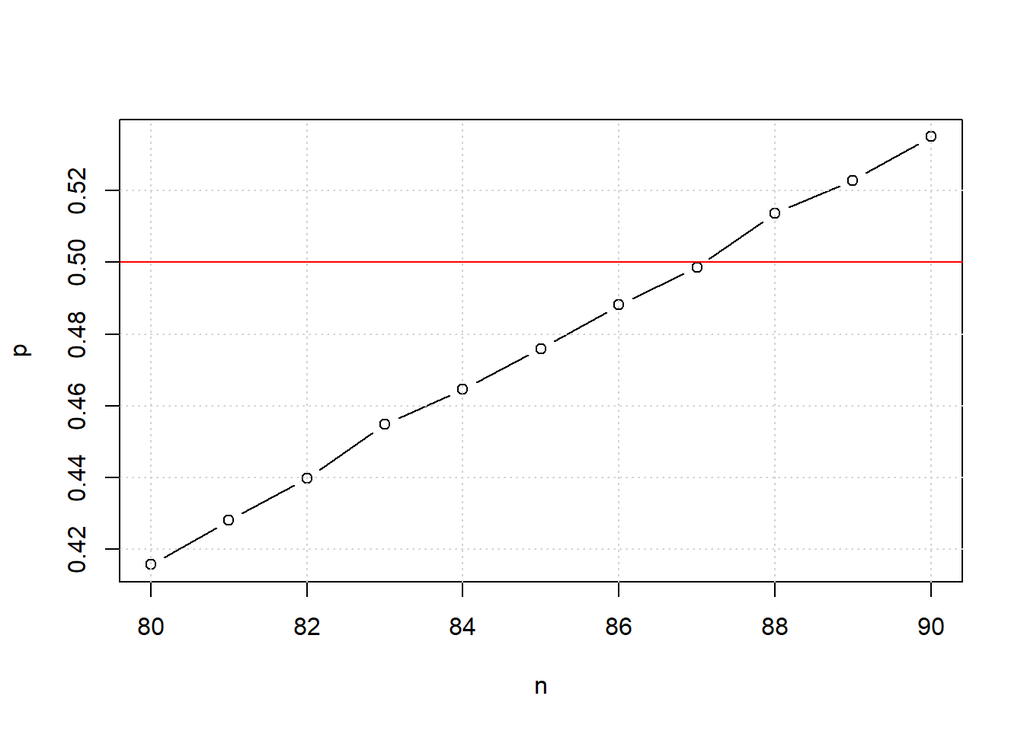

```r
plot(n,p,type='b')
grid()
abline(h=0.5,col='red')
```

Let us repeat the simulation for multiple trials of n=87:

```r
p=c()
for (i in 1:10) {
  p=c(p,birthday(87,100000,3))
}
```

What do the results say?

```r
p
```

```
##  [1] 0.49879 0.49848 0.49865 0.49840 0.49865 0.49965 0.49936 0.49902
##  [9] 0.49930 0.50248
```

This is going to be difficult. Sometimes the results are above 50% and sometimes below. We can pool these 10 trials together but … it might not be enough:

```r
mean(p)
```

```
## [1] 0.499278
```

We can use a t-test:

```r
t.test(p,mu=0.5)
```

```
##
##  One Sample t-test
##
## data:  p
## t = -1.9071, df = 9, p-value = 0.08887
## alternative hypothesis: true mean is not equal to 0.5
## 95 percent confidence interval:
##  0.4984216 0.5001344
## sample estimates:
## mean of x
##  0.499278
```

Unfortunately, the 95% confidence interval includes the 0.5 value. We simply don’t have enough samples to make a conclusion.

We can simply increase the number of samples and check again. Let us try 1e6 samples:

```r
p=c()
for (i in 1:10) {
  p=c(p,birthday(87,1000000,3))
}
t.test(p,mu=0.5)
```

```
##
##  One Sample t-test
##
## data:  p
## t = -3.6995, df = 9, p-value = 0.004925
## alternative hypothesis: true mean is not equal to 0.5
## 95 percent confidence interval:
##  0.4990550 0.4997722
## sample estimates:
## mean of x
## 0.4994136
```

From this we can conclude that n=87 is not sufficient to ensure 50% of the time that 3 people share the same birthday.

We can check 88, but that is relatively easy so we can drop back to 100K samples:

```r
p=c()
for (i in 1:10) {
  p=c(p,birthday(88,100000,3))
}
t.test(p,mu=0.5)
```

```
##
##  One Sample t-test
##
## data:  p
## t = 22.177, df = 9, p-value = 3.644e-09
## alternative hypothesis: true mean is not equal to 0.5
## 95 percent confidence interval:
##  0.5095924 0.5117716
## sample estimates:
## mean of x
##  0.510682
```

Which is clearly significant.

Conclusion: need n=88 people to ensure 50% change that 3 or more share the same birthday.